# NYPD Shooting Incidents

Violent crime is an ongoing problem in many American cities. Insight into this problem would be of great benefit to law enforcement, policy makers, city planners and residents. The objective of this analysis is to determine what patterns exists in the historical data set of shooting incidents in New York City, USA. What are some common themes that can be discovered regarding these shootings? In particular, when and where do shootings occur?

## Libraries

These libraries were used to work with the data. If the following code fails to execute, the libraries may need to be installed.

```r
library(tidyverse)
library(lubridate)
```

## Overview of the Data

Import the data into the workspace, directly from the source. If there are problems accessing the URL, import the file locally if it exists on the local machine using the commented line of code.

```r
raw <- read_csv("https://data.cityofnewyork.us/api/views/833y-fsy8/rows.csv?accessType=DOWNLOAD")
#raw <- read_csv(file.choose())
```

The data set used in this analysis has been retrieved from the [NYC Open Data](https://opendata.cityofnewyork.us/overview/) website, which seems to be reputable based on the transparency the organization has on their standards of handling and collecting data. Metadata such as descriptions of what data are contained for each column can be found [here](https://data.cityofnewyork.us/Public-Safety/NYPD-Shooting-Incident-Data-Historic-/833y-fsy8).

```r
head(raw)
```

```
## # A tibble: 6 x 19
##   INCIDENT_KEY OCCUR_DATE OCCUR_TIME BORO          PRECINCT JURISDICTION_CODE
##          <dbl> <chr>      <time>     <chr>            <dbl>             <dbl>
## 1    201575314 08/23/2019 22:10      QUEENS             103                 0
## 2    205748546 11/27/2019 15:54      BRONX               40                 0
## 3    193118596 02/02/2019 19:40      MANHATTAN           23                 0
## 4    204192600 10/24/2019 00:52      STATEN ISLAND      121                 0
## 5    201483468 08/22/2019 18:03      BRONX               46                 0
## 6    198255460 06/07/2019 17:50      BROOKLYN            73                 0
## # ... with 13 more variables: LOCATION_DESC <chr>,
## #   STATISTICAL_MURDER_FLAG <lgl>, PERP_AGE_GROUP <chr>, PERP_SEX <chr>,
## #   PERP_RACE <chr>, VIC_AGE_GROUP <chr>, VIC_SEX <chr>, VIC_RACE <chr>,
## #   X_COORD_CD <dbl>, Y_COORD_CD <dbl>, Latitude <dbl>, Longitude <dbl>,
## #   Lon_Lat <chr>
```

Columns representing categorical variables are of type `character`. Nothing interesting is revealed when `summary` is executed on such a data set with columns encoded this way. These columns are converted to type `factor` to illustrate the various categories contained therein.

```r
raw %>%
  mutate_if(is.character, as.factor) %>%
  summary()
```

```
##   INCIDENT_KEY            OCCUR_DATE     OCCUR_TIME                  BORO
##  Min.   :  9953245   07/05/2020:   47   Length:23568      BRONX        :6700
##  1st Qu.: 55317014   09/04/2011:   31   Class1:hms        BROOKLYN     :9722
##  Median : 83365370   07/26/2020:   29   Class2:difftime   MANHATTAN    :2921
##  Mean   :102218616   08/11/2007:   26   Mode  :numeric    QUEENS       :3527
##  3rd Qu.:150772442   08/15/2020:   25                     STATEN ISLAND: 698
##  Max.   :222473262   09/04/2006:   25
##                      (Other)   :23385
##     PRECINCT      JURISDICTION_CODE                   LOCATION_DESC
##  Min.   :  1.00   Min.   :0.0000    MULTI DWELL - PUBLIC HOUS: 4230
##  1st Qu.: 44.00   1st Qu.:0.0000    MULTI DWELL - APT BUILD  : 2551
##  Median : 69.00   Median :0.0000    PVT HOUSE                :  858
##  Mean   : 66.21   Mean   :0.3323    GROCERY/BODEGA           :  572
##  3rd Qu.: 81.00   3rd Qu.:0.0000    BAR/NIGHT CLUB           :  558
##  Max.   :123.00   Max.   :2.0000    (Other)                  : 1218
##                   NA's   :2         NA's                     :13581
##  STATISTICAL_MURDER_FLAG PERP_AGE_GROUP PERP_SEX              PERP_RACE
##  Mode :logical           18-24  :5448   F   :  334   BLACK         :9855
##  FALSE:19080             25-44  :4613   M   :13305   WHITE HISPANIC:1961
##  TRUE :4488              UNKNOWN:3156   U   : 1504   UNKNOWN       :1869
##                          <18    :1354   NA's: 8425   BLACK HISPANIC:1081
##                          45-64  : 481                WHITE         : 255
##                          (Other):  57                (Other)       : 122
##                          NA's   :8459                NA's          :8425
##  VIC_AGE_GROUP   VIC_SEX                             VIC_RACE
##  <18    : 2525   F: 2195   AMERICAN INDIAN/ALASKAN NATIVE:    9
##  18-24  : 9000   M:21353   ASIAN / PACIFIC ISLANDER      :  320
##  25-44  :10287   U:   20   BLACK                         :16846
##  45-64  : 1536             BLACK HISPANIC                : 2244
##  65+    :  155             UNKNOWN                       :  102
##  UNKNOWN:   65             WHITE                         :  615
##                            WHITE HISPANIC                : 3432
##    X_COORD_CD        Y_COORD_CD        Latitude       Longitude
##  Min.   : 914928   Min.   :125757   Min.   :40.51   Min.   :-74.25
##  1st Qu.: 999900   1st Qu.:182565   1st Qu.:40.67   1st Qu.:-73.94
##  Median :1007645   Median :193482   Median :40.70   Median :-73.92
##  Mean   :1009363   Mean   :207312   Mean   :40.74   Mean   :-73.91
##  3rd Qu.:1016807   3rd Qu.:239163   3rd Qu.:40.82   3rd Qu.:-73.88
##  Max.   :1066815   Max.   :271128   Max.   :40.91   Max.   :-73.70
##
##                                           Lon_Lat
##  POINT (-73.88151172399995 40.67141166300007) :   80
##  POINT (-73.84760778699997 40.88745131300004) :   52
##  POINT (-73.91339091999998 40.670655072000045):   52
##  POINT (-73.91284696199995 40.670366460000025):   51
##  POINT (-73.77590919399995 40.680048726000045):   49
##  POINT (-73.88143295699997 40.67110691100004) :   48
##  (Other)                                      :23236
```

The data set contains various demographic information about the perpetrator and the victim, such as their sex, race and age. Also included is information about where the crime took place: coordinates, borough, location description, etc. The date and the time the incident occurred is also available, though it would be preferable if the two columns were combined into a DATATIME column. The age columns are categorical, rather than numeric. There appear to be a few outliers in most columns, as evidenced by the *(other)* designation.

## Tidying and Transforming the Data

```r
na <- "UNKNOWN"

shooting_data <- raw %>%
  select(-c(INCIDENT_KEY , X_COORD_CD, Y_COORD_CD, Latitude, Longitude, Lon_Lat)) %>%
  unite("DATETIME", OCCUR_DATE, OCCUR_TIME, sep = " ") %>%
  mutate(DATETIME = mdy_hms(DATETIME)) %>%
  replace_na(list(LOCATION_DESC = na, PERP_AGE_GROUP = na, PERP_SEX = "U", PERP_RACE = na,
                  VIC_AGE_GROUP = na, VIC_SEX = "U", VIC_RACE = na, JURISDICTION_CODE = -1)) %>%
  mutate_if(is.character, as.factor)
```

This code chunk ensures that the resulting transformed data set:

1. Contains columns that contain potentially useful information
2. Date and time data are combined and converted into a useful data type
3. That missing values are handled in a meaningful way
4. That `character` type columns have been converted to a useful format for analysis

### Handling of Missing Values

Inspecting the `summary` of the raw data, it can be observed that several categorical variables have entries for *UNKNOWN*, as well as `na`. It would seem fitting that all `na` entries in these columns be replaced with *UNKNOWN* or *U*, in the case of the `*_SEX` columns. The `na` entries in the `JURISDICTION_CODE` have been set to `-1`, since data in that column are expected to be integers.

This test should ensure that all `na` entries have been taken care of.

```r
for (col in colnames(shooting_data)) {
  tib <- shooting_data %>% filter(is.na(shooting_data[col]))
  if (dim(tib)[1] > 0) {
    print(tib)
    break
  }
}
```

## Visualizations and Analysis

Some interesting information about the location of shootings and the demographics of the victims and perpetrators can be seen from the summary of the data:

```r
summary(shooting_data)
```

```
##     DATETIME                              BORO         PRECINCT
##  Min.   :2006-01-01 02:00:00   BRONX        :6700   Min.   :  1.00
##  1st Qu.:2008-12-30 04:27:00   BROOKLYN     :9722   1st Qu.: 44.00
##  Median :2012-02-26 03:35:00   MANHATTAN    :2921   Median : 69.00
##  Mean   :2012-10-04 05:23:12   QUEENS       :3527   Mean   : 66.21
##  3rd Qu.:2016-02-28 00:01:00   STATEN ISLAND: 698   3rd Qu.: 81.00
##  Max.   :2020-12-31 23:45:00                        Max.   :123.00
##
##  JURISDICTION_CODE                   LOCATION_DESC   STATISTICAL_MURDER_FLAG
##  Min.   :-1.0000   UNKNOWN                  :13581   Mode :logical
##  1st Qu.: 0.0000   MULTI DWELL - PUBLIC HOUS: 4230   FALSE:19080
##  Median : 0.0000   MULTI DWELL - APT BUILD  : 2551   TRUE :4488
##  Mean   : 0.3321   PVT HOUSE                :  858
##  3rd Qu.: 0.0000   GROCERY/BODEGA           :  572
##  Max.   : 2.0000   BAR/NIGHT CLUB           :  558
##                    (Other)                  : 1218
##  PERP_AGE_GROUP  PERP_SEX                           PERP_RACE
##  UNKNOWN:11615   F:  334   AMERICAN INDIAN/ALASKAN NATIVE:    2
##  18-24  : 5448   M:13305   ASIAN / PACIFIC ISLANDER      :  120
##  25-44  : 4613   U: 9929   BLACK                         : 9855
##  <18    : 1354             BLACK HISPANIC                : 1081
##  45-64  :  481             UNKNOWN                       :10294
##  65+    :   54             WHITE                         :  255
##  (Other):    3             WHITE HISPANIC                : 1961
##  VIC_AGE_GROUP   VIC_SEX                             VIC_RACE
##  <18    : 2525   F: 2195   AMERICAN INDIAN/ALASKAN NATIVE:    9
##  18-24  : 9000   M:21353   ASIAN / PACIFIC ISLANDER      :  320
##  25-44  :10287   U:   20   BLACK                         :16846
##  45-64  : 1536             BLACK HISPANIC                : 2244
##  65+    :  155             UNKNOWN                       :  102
##  UNKNOWN:   65             WHITE                         :  615
##                            WHITE HISPANIC                : 3432
```

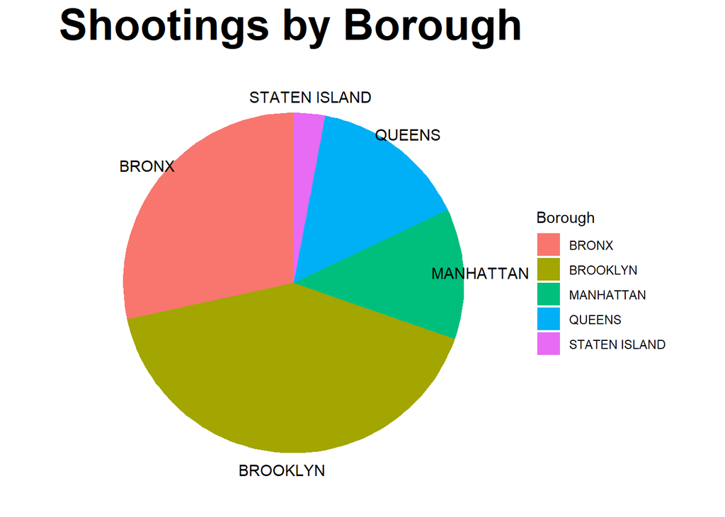

```r
shooting_data %>%
  group_by(BORO) %>%
  tally() %>%
  rename(Borough = BORO) %>%
  ggplot(aes(x = "", y = n, fill = Borough)) +
  geom_bar(stat="identity", width=1) +
  coord_polar(theta="y", start=0) +
  geom_text(aes(x=1.6, label=Borough),
  position = position_stack(vjust=0.5)) +
  ggtitle("Shootings by Borough") +
  theme_void() +
  theme(plot.title = element_text(size = 30, face = "bold"))
```

According to this visual, Brooklyn and The Bronx appear to have a disproportionate share of shooting incidents. This raises questions as to why this is. Do these areas have a favorable environment for crime? Are these areas simply more populated? It would be reasonable to hypothesize that population count and incidents of shootings have a positive relationship. These would be good followup questions for a future analysis.

### Temporal Data vs Shooting Frequency

It is not obvious from looking at the `summary` when shootings take place. Bar graphs should assist with illustrating possible time dependence on the frequency of shootings.

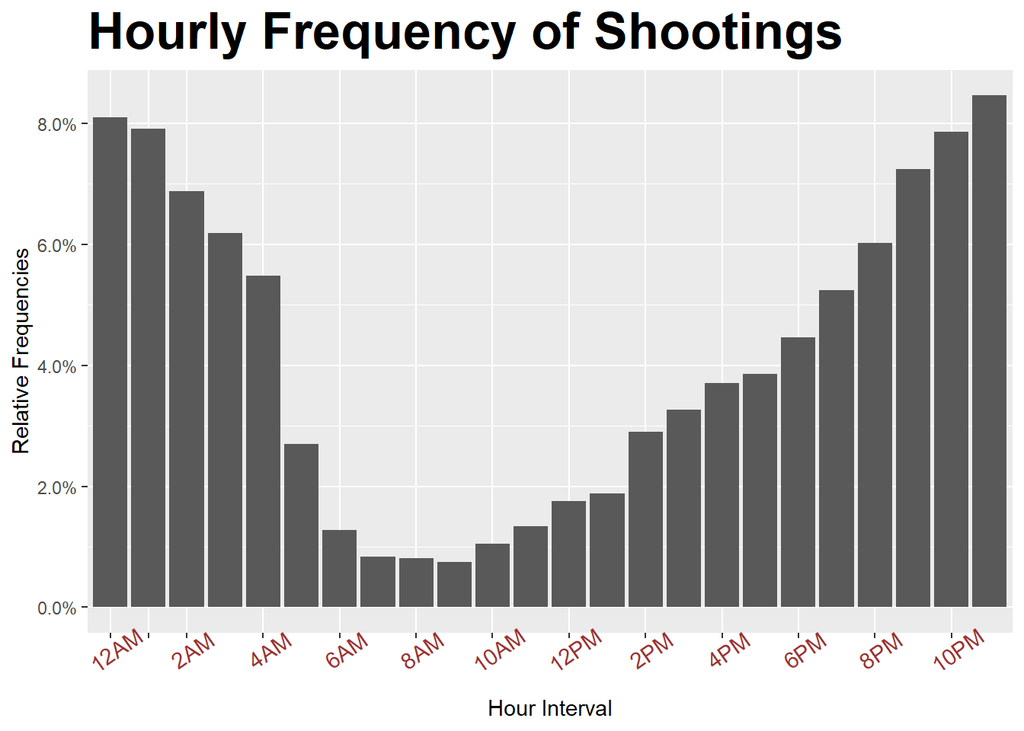

```r
#Label hour intervals so this graph is easier to understand
hrLabel <- function() {
  hrs <- rep("", 24)
  fst <- 12
  lst <- 1
  t1 <- "AM"
  t2 <- "AM"
  for (i in 1:24) {
    if (i %% 2 == 1) {
      hrs[i] = paste(fst, t1, sep = "")
    } else {
      hrs[i] = " "
    }
    fst <- (fst + 1) %% 12
    lst <- (lst + 1) %% 12
    if (fst == 0) {
      fst <- 12
      t1 <- "PM"
    }
    if (lst == 0) {
      lst <- 12
      t2 <- "PM"
    }
  }
  hrs
}

shooting_data %>%
  mutate(Hour = hour(DATETIME)) %>%
  ggplot(aes(Hour+1)) +
  geom_bar(aes(y = (..count..)/sum(..count..))) +
  scale_y_continuous(labels=scales::percent) +
  ggtitle("Hourly Frequency of Shootings") +
  xlab("Hour Interval") +
  ylab("Relative Frequencies") +
  scale_x_discrete(limits=hrLabel()) +
  theme(plot.title = element_text(size = 25, face = "bold")) +
  theme(axis.text.x = element_text(color = "#993333",
                                     size = 11, angle = 35))
```

Are there certain times of the day when shootings are more frequent? This illustration seems to indicate that is the case. The frequency of shootings seems to vary, on average, during the course of the day, with a peak around 8% of the day’s incidents from 11PM-12AM, falling into the morning to a minimum of less than 1% from 9AM - 10AM and rising until 11PM. Are shootings more likely to occur under the cover of darkness at night?

The distribution of the number of shootings takes on a roughly parabolic shape, which might indicate that a polynomial model can be fitted to the relative frequency of shootings per hour, as a percentage of the day’s incident totals.

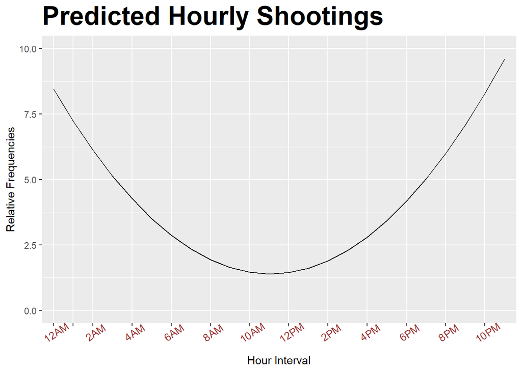

```r
hrData <- shooting_data %>%
  mutate(Hour = hour(DATETIME)) %>%
  group_by(Hour) %>%
  count() %>%
  data.frame()

hrData$n = hrData$n / sum(hrData$n)

hrModel <- lm(hrData$n~polym(hrData$Hour,degree=2,raw=TRUE))

data.frame(1:24) %>%
  ggplot(aes(x = 1:24, y = predict(hrModel) * 100)) +
  geom_line() +
  ggtitle("Predicted Hourly Shootings") +
  xlab("Hour Interval") +
  ylab("Relative Frequencies") +
  scale_x_discrete(limits=hrLabel()) +
  theme(plot.title = element_text(size = 25, face = "bold")) +
  theme(axis.text.x = element_text(color = "#993333",
                                     size = 10, angle = 35)) +
  scale_y_continuous(limits=c(0,10))
```

```r
summary(hrModel)
```

```
##
## Call:
## lm(formula = hrData$n ~ polym(hrData$Hour, degree = 2, raw = TRUE))
##
## Residuals:
##       Min        1Q    Median        3Q       Max
## -0.015938 -0.005216  0.001880  0.006973  0.012173
##
## Coefficients:
##                                               Estimate Std. Error t value
## (Intercept)                                  8.448e-02  4.969e-03   17.00
## polym(hrData$Hour, degree = 2, raw = TRUE)1 -1.275e-02  1.001e-03  -12.75
## polym(hrData$Hour, degree = 2, raw = TRUE)2  5.765e-04  4.202e-05   13.72
##                                             Pr(>|t|)
## (Intercept)                                 9.37e-14 ***
## polym(hrData$Hour, degree = 2, raw = TRUE)1 2.37e-11 ***
## polym(hrData$Hour, degree = 2, raw = TRUE)2 5.93e-12 ***
## ---
## Signif. codes:  0 '***' 0.001 '**' 0.01 '*' 0.05 '.' 0.1 ' ' 1
##
## Residual standard error: 0.008799 on 21 degrees of freedom
## Multiple R-squared:  0.9014, Adjusted R-squared:  0.892
## F-statistic:    96 on 2 and 21 DF,  p-value: 2.725e-11
```

Based on the R-squared value, ~90% of the variation of shootings during the day is explained by the time of day. The near-zero p-value indicates that it is unlikely this relationship is by chance alone and that there is a correlation between frequency of shootings during the day and the time of day.

**Please note** that this does not show that shooters commit their crimes based on what time it is - they might not necessarily plan when they will commit a murder. There could be a confounding variable at work behind the scenes that correlates with both the time of day and frequency of shootings that could provide a causal explanation for this relationship.

Do shootings tend to occur when clandestine criminal acts are taking place, such as when a drug deal goes bad? Are criminals too busy at work during the day to carry out a crime?

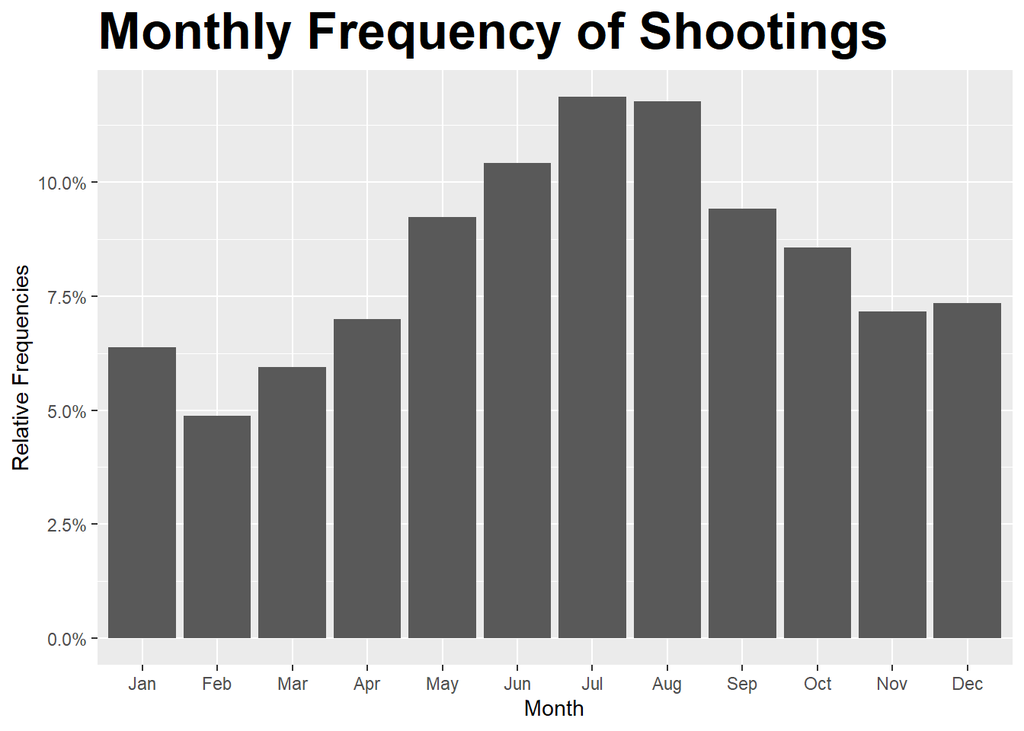

```r
shooting_data %>%
  mutate(Month = month(DATETIME)) %>%
  ggplot(aes(Month)) +
  geom_bar(aes(y = (..count..)/sum(..count..))) +
  scale_y_continuous(labels=scales::percent) +
  ggtitle("Monthly Frequency of Shootings") +
  ylab("Relative Frequencies") +
  scale_x_discrete(limits = month.abb) +
  theme(plot.title = element_text(size = 25, face = "bold"))
```

It also appears that the frequency of shootings vary by month. There appears to be a steady increase of incidents starting in the dead of winter and peaking in the middle of summer, only to decline into the winter. This leads to the question: Does the summer season have, on average, a disproportionate number of incidents?

```r
summerCount <- shooting_data %>%
  filter(month(DATETIME) >= 6 & month(DATETIME) <= 8) %>%
  nrow()
```

`summerCount` is the number of rows corresponding to a shooting which has taken place from June through August, inclusive.

A one proportion test would be ideal for determining whether or not summer has an unusual incidence of reported shootings. If the null hypothesis is true, then every month would have about the same rate of shootings, about 8.33% of the year’s shootings. Therefore, the three summer months would be expected to account for 25% of the total year’s shootings.

```r
numTrials <- nrow(shooting_data)
prop.test(x=summerCount, n = numTrials, p=0.25, correct = F)
```

```
##
##  1-sample proportions test without continuity correction
##
## data:  summerCount out of numTrials, null probability 0.25
## X-squared = 1034.4, df = 1, p-value < 2.2e-16
## alternative hypothesis: true p is not equal to 0.25
## 95 percent confidence interval:
##  0.3346917 0.3467926
## sample estimates:
##         p
## 0.3407162
```

The small absolute value of the p-value indicates that there are a disproportionate number of shootings during the summer. In fact, the expected number of shootings that occur during the summer is 34%, with a small margin of error. This suggests that summer sees more cases than would be expected due only to chance.

This leads to yet more questions: Is there a relationship between seasonal temperature and shootings? What demographic patters take place during summer and during the year which would lead to an increase in shootings? Are shootings more likely to be reported during warmer months?

## Conclusion

### Sources of Bias

A common perception about clandestine acts, such as violent crime, is that they take place under the cover of darkness, are usually accompanied by other criminal acts and that these crimes are concentrated in certain places. I believe that this is typically the case. It is likely that I’ve analyzed the data with these assumptions in mind, when there are actually other trends that are more fundamental or that contradict my beliefs. To mitigate this, I have incorporated into the analysis statistical tests to make assertions and have attempted to be careful about what the results imply. I’ve also made an attempt to be open minded and consider possible confounding variables at work.

It is also possible there is bias in the data itself. Recall bias might have occurred when collecting the data, especially when the perpetrator hasn’t been taken into custody. Law Enforcement and witnesses might be more inclined to make mistakes when giving details about the perpetrator of the shooting. That is why I did not explore demographic data in detail.

The date the incidents were reported to have taken place might differ significantly from when the shooting actually took place, as reports are made after the fact and usually involve estimation. Such errors have the potential to invalidate the findings regarding shootings and time of the day.